# R Notebook

#——————————————————-# # Ejemplo: Empleados de Midwestern bank (1965) # # ——————————————————# # ID = C?digo del empleado # # SALBEG = Salario inicial # # GENDER = G?nero # # JOBTIME = Meses en el trabajo # # AGE = Edad (a?os) # # SALNOW = Salario actual # # EDLEVEL = Experiencia acad?mica (a?os) # # WORKEXP = Experiencia laboral previa (a?os) # # JOBCAT = Categor?a laboral # # MINORITY = Pertenece a minor?a racial # #——————————————————-#

```r
Bank <- read.delim("BwBankTab.dat" )
head(Bank)
```

|  | ID | SALBEG | GENDER | JOBTIME | AGE | SALNOW | EDLEVEL | WORKEXP | JOBCAT | MINORITY |
| --- | --- | --- | --- | --- | --- | --- | --- | --- | --- | --- |
| 1 | 628 | 8400 | 0 | 81 | 28 | 16080 | 16 | 0.25 | 4 | 0 |
| 2 | 630 | 24000 | 0 | 73 | 40 | 41400 | 16 | 12.50 | 5 | 0 |
| 3 | 632 | 10200 | 0 | 83 | 31 | 21960 | 15 | 4.08 | 5 | 0 |
| 4 | 633 | 8700 | 0 | 93 | 31 | 19200 | 16 | 1.83 | 4 | 0 |
| 5 | 635 | 17400 | 0 | 83 | 41 | 28350 | 19 | 13.00 | 5 | 0 |
| 6 | 637 | 12996 | 0 | 80 | 29 | 27250 | 18 | 2.42 | 4 | 0 |

```r
# Asignar etiquetas y valores perdidos
Bank$GENDER <- as.factor(Bank$GENDER); levels(Bank$GENDER)<- c("Hombre","Mujer",NA)
Bank$MINORITY <- as.factor(Bank$MINORITY); levels(Bank$MINORITY)<- c("Blanco","No blanco",NA)
Bank$JOBCAT <- as.factor(Bank$JOBCAT)
levels(Bank$JOBCAT)<- c(NA, "Oficinista", "Asistente", "Seguridad",
                        "Acad?mico", "Empleado", "Ejecutivo", "T?cnico" )
Bank$SALBEG[Bank$SALBEG == 0] <- NA
Bank$JOBTIME[Bank$JOBTIME == 0] <- NA
Bank$AGE[Bank$AGE == 0] <- NA
Bank$SALNOW[Bank$SALNOW == 0] <- NA
Bank$EDLEVEL[Bank$EDLEVEL == 0] <- NA
Bank$WORKEXP[Bank$WORKEXP == 0] <- NA

summary(Bank)
```

```
       ID             SALBEG         GENDER       JOBTIME           AGE
 Min.   : 626.0   Min.   : 3600   Hombre:257   Min.   :63.00   Min.   :23.00
 1st Qu.: 748.2   1st Qu.: 5085   Mujer :212   1st Qu.:72.00   1st Qu.:28.00
 Median : 877.5   Median : 6000   NA's  :  5   Median :81.00   Median :32.00
 Mean   : 876.6   Mean   : 6826                Mean   :81.15   Mean   :36.77
 3rd Qu.:1002.8   3rd Qu.: 7200                3rd Qu.:90.00   3rd Qu.:46.00
 Max.   :1129.0   Max.   :31992                Max.   :98.00   Max.   :64.00
                  NA's   :6                    NA's   :4       NA's   :2
     SALNOW         EDLEVEL         WORKEXP              JOBCAT
 Min.   : 6300   Min.   : 8.00   Min.   : 0.170   Oficinista:223
 1st Qu.: 9630   1st Qu.:12.00   1st Qu.: 2.000   Asistente :136
 Median :11640   Median :12.00   Median : 4.920   Acad?mico : 41
 Mean   :13792   Mean   :13.49   Mean   : 8.415   Empleado  : 32
 3rd Qu.:14910   3rd Qu.:15.00   3rd Qu.:12.000   Seguridad : 27
 Max.   :54000   Max.   :21.00   Max.   :39.670   (Other)   : 11
 NA's   :3       NA's   :3       NA's   :24       NA's      :  4
      MINORITY
 Blanco   :370
 No blanco: 98
 NA's     :  6
```

```r
Bank <- na.omit(Bank)
```

[output not shown]

[output cut: 16 more lines]

[output not shown]

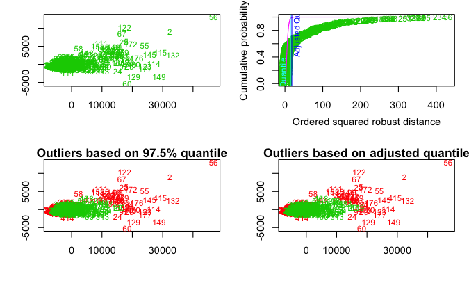

```r
#--------------------------------------------------------------------------------------- #
#  Ejemplo: Estimadores robustos                                                       #
# Ver Filzmoser et al. (2005) Multivariate outlier detection in exploration geochemistry #
#----------------------------------------------------------------------------------------#

library(mvoutlier)
aq.plot(dat)
```

```
Remove outliers with left-click, stop with right-click on plotting device
$outliers
NULL
```

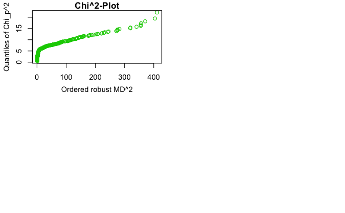

```r
chisq.plot(dat)
```

[output not shown]

[output cut: 252 more lines]

```
 7.020005  3.697607  4.570940  4.255081  3.306581  3.167114  5.102523  3.283936
      410       411       412       413       414       415       416       417
 6.650987  5.509037  4.824769  6.544325  6.246759  8.555007  5.735875  5.652905
      418       419       420       421       422       423       424       425
 4.814955  4.991875  5.239361  5.922446  6.876882  6.859634  3.887535  5.489828
      426       427       428       429       430       431       432       433
 5.158464  4.754475  5.623100  3.912462  5.364540  5.396316  7.161074  3.594341
      434       435       438       439       440       442       443       444
 3.974749  3.531205  4.157498  4.662979  2.497973  5.446629  6.034411  3.691960
      453       454       455       456       460       461       462       463
 4.208914  5.860897  5.099340  4.673734  5.572241  4.855922  3.185242  5.947536
      464       465       467       468       469       470       471       473
 3.767648  3.846868  4.363910  5.880781  4.961740  4.486412  2.968862  5.264495
      474
 3.752408
```

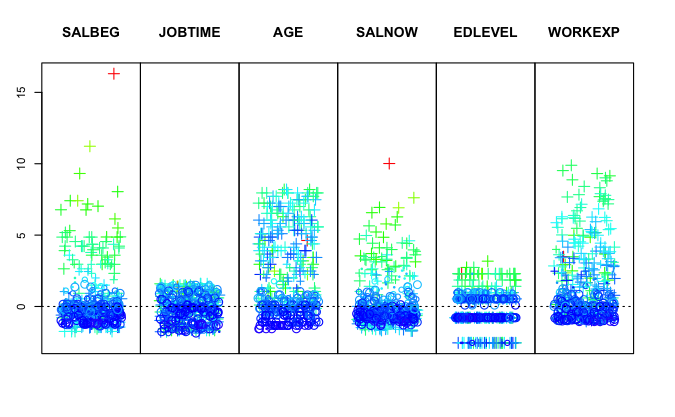

```r
uni.plot(dat,symb = TRUE)
```

Lo que estan pintados de rojo, son los posibles outlier basado en la distancia de Mahalanobis

```r
Bank[c(56,234),]
```

|  | ID | SALBEG | GENDER | JOBTIME | AGE | SALNOW | EDLEVEL | WORKEXP | JOBCAT | MINORITY |
| --- | --- | --- | --- | --- | --- | --- | --- | --- | --- | --- |
| 56 | 779 | 31992 | Hombre | 96 | 49 | 54000 | 19 | 16.58 | T?cnico | Blanco |
| 245 | 763 | 6600 | Mujer | 84 | 61 | 11640 | 8 | 2.92 | Oficinista | Blanco |

# Outliers Multivariados (Otros m?todos)

# Metodo de componentes principales

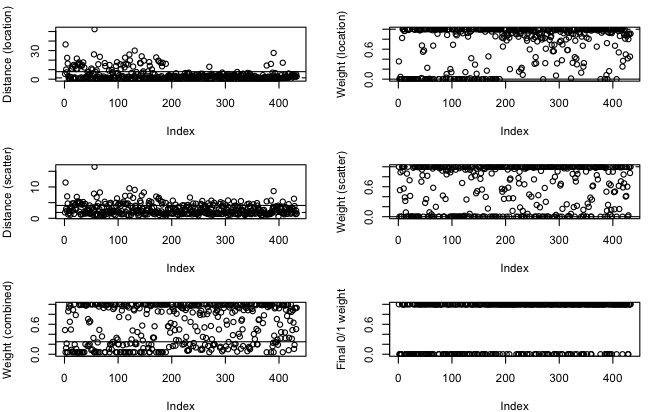

```r
# PCOut Method (robust principal components - m?s adecuado para grandes dimensiones)
# Ver Filzmoser et al. (2008) Outlier identification in high dimensions
outlier=pcout(dat, makeplot = TRUE)
```

```r
outlier
```

[output not shown]

[output cut: 699 more lines]

```
       468        469        470        471        473        474
 6.2507713  3.9093645  1.8684658  1.3135795  2.4296990  1.4972830

$M1
33.33333%
 1.390833

$const1
[1] 7.899433

$M2
[1] 1.858655

$const2
[1] 4.100231
```

```r
Bank[order(outlier$wfinal,decreasing=F)[1:10],]
```

|  | ID | SALBEG | GENDER | JOBTIME | AGE | SALNOW | EDLEVEL | WORKEXP | JOBCAT | MINORITY |
| --- | --- | --- | --- | --- | --- | --- | --- | --- | --- | --- |
| 2 | 630 | 24000 | Hombre | 73 | 40 | 41400 | 16 | 12.50 | Empleado | Blanco |
| 5 | 635 | 17400 | Hombre | 83 | 41 | 28350 | 19 | 13.00 | Empleado | Blanco |
| 6 | 637 | 12996 | Hombre | 80 | 29 | 27250 | 18 | 2.42 | Acad?mico | Blanco |
| 15 | 659 | 13200 | Hombre | 64 | 31 | 19020 | 19 | 2.25 | Empleado | Blanco |
| 17 | 669 | 13500 | Hombre | 81 | 30 | 22200 | 19 | 5.17 | Acad?mico | Blanco |
| 20 | 685 | 11004 | Hombre | 89 | 34 | 27500 | 17 | 3.17 | Acad?mico | Blanco |
| 23 | 697 | 16992 | Hombre | 85 | 43 | 27700 | 20 | 11.17 | T?cnico | Blanco |
| 24 | 702 | 8700 | Hombre | 65 | 28 | 28000 | 16 | 1.58 | Acad?mico | Blanco |
| 25 | 704 | 13992 | Hombre | 65 | 39 | 22000 | 19 | 10.75 | Empleado | Blanco |
| 26 | 706 | 12804 | Hombre | 78 | 30 | 27250 | 19 | 2.92 | Acad?mico | Blanco |

Ya no identifica quien es un outlier que ya usa el parametro final $wfinal , a partir de que una distancia que podria ser un outlier

# Metodo del signo

```r
# Sign Method
outlier1=sign2(dat)
outlier1
```

[output not shown]

[output cut: 87 more lines]

```
       418        419        420        421        422        423        424
 2.2225913  1.6197485  4.5363461  3.3151066  4.4739972  5.0718242  0.8077400
       425        426        427        428        429        430        431
 2.7501530  2.0623626  2.7415618  4.3661093  2.3519583  2.4616736  1.7823054
       432        433        434        435        438        439        440
 5.0430407  1.7598213  1.3141064  1.1456339  3.0155977  3.8278787  1.6130282
       442        443        444        453        454        455        456
 2.1757470  2.8052903  1.1252997  2.0248713  4.6680067  3.7965309  2.3495007
       460        461        462        463        464        465        467
 3.5305756  1.6727706  1.4919644  3.7121842  2.4367013  1.6995664  2.9988755
       468        469        470        471        473        474
 6.7734068  3.9583864  1.6298742  1.3983481  3.0459681  1.6394636

$const
[1] 3.801233
```

```r
Bank[order(outlier1$x.dist,decreasing=T)[1:10],]
```

|  | ID | SALBEG | GENDER | JOBTIME | AGE | SALNOW | EDLEVEL | WORKEXP | JOBCAT | MINORITY |
| --- | --- | --- | --- | --- | --- | --- | --- | --- | --- | --- |
| 56 | 779 | 31992 | Hombre | 96 | 49 | 54000 | 19 | 16.58 | T?cnico | Blanco |
| 2 | 630 | 24000 | Hombre | 73 | 40 | 41400 | 16 | 12.50 | Empleado | Blanco |
| 122 | 950 | 21000 | Hombre | 83 | 49 | 26700 | 16 | 21.50 | T?cnico | Blanco |
| 67 | 808 | 18996 | Hombre | 86 | 42 | 26400 | 16 | 12.50 | Empleado | Blanco |
| 149 | 1005 | 11004 | Hombre | 97 | 37 | 41500 | 16 | 5.83 | Empleado | Blanco |
| 132 | 973 | 18000 | Hombre | 96 | 39 | 44250 | 19 | 10.00 | T?cnico | Blanco |
| 415 | 948 | 17640 | Hombre | 66 | 35 | 40000 | 16 | 10.67 | Empleado | No blanco |
| 55 | 778 | 18000 | Hombre | 66 | 34 | 34500 | 18 | 4.17 | T?cnico | Blanco |
| 60 | 786 | 6300 | Hombre | 82 | 29 | 32000 | 15 | 2.83 | Asistente | Blanco |
| 5 | 635 | 17400 | Hombre | 83 | 41 | 28350 | 19 | 13.00 | Empleado | Blanco |

# Metodo de densidades locales . Tiene que colocar el tamaño de la vencidad

```r
# Densidad Local
library(DMwR)
lof=lofactor(dat,10) # se coloca el tamaño de vencidad 10
lof
```

```
  [1] 1.1393708 1.8043773 0.9733684 0.9876981 1.5657395 0.9711284 1.0390732
  [8] 1.1209161 1.2113814 1.0375532 0.9981858 1.0618558 0.9978690 1.0016641
 [15] 1.3172143 1.4919040 1.0445935 1.2847987 1.1814037 1.0513454 1.2253197
 [22] 1.1004882 1.4972860 1.4505971 1.0957708 0.9810295 0.9764020 1.1984752
 [29] 1.0858892 1.0786706 0.9876739 1.0414522 1.0017625 0.9767478 1.1389515
 [36] 1.0544807 0.9859713 0.9581779 1.0396700 1.8125769 1.0544467 0.9440444
 [43] 1.4622282 1.1730719 1.0080436 1.1386073 0.9853013 1.1922512 0.9864758
 [50] 0.9818134 0.9921218 0.9914694 1.0000175 1.4652223 1.2495442 3.2296080
 [57] 0.9595323 2.5916561 0.9856809 1.6913215 0.9668383 0.9594768 1.0011015
 [64] 1.0242748 1.0415129 1.8176961 1.1476953 0.9717981 1.1021634 1.0142587
 [71] 0.9863626 1.0015873 0.9732796 1.0568091 1.1160381 0.9707855 1.2361668
 [78] 1.1602275 0.9954576 1.1281323 1.1946648 1.4053119 1.0264286 0.9637269
 [85] 1.0268336 1.0682270 1.0331171 1.0459900 0.9823546 1.0296263 1.3529825
 [92] 1.1191030 1.0501017 0.9698387 1.1126859 1.0899388 1.0500227 1.0676195
 [99] 1.0191726 1.1980618 1.1210748 1.0981898 1.2674473 0.9725358 1.0529349
```

[output cut: 47 more lines]

```r
Bank[order(lof,decreasing=T)[1:10],]
```

|  | ID | SALBEG | GENDER | JOBTIME | AGE | SALNOW | EDLEVEL | WORKEXP | JOBCAT | MINORITY |
| --- | --- | --- | --- | --- | --- | --- | --- | --- | --- | --- |
| 56 | 779 | 31992 | Hombre | 96 | 49 | 54000 | 19 | 16.58 | T?cnico | Blanco |
| 58 | 783 | 11100 | Hombre | 82 | 44 | 13848 | 16 | 12.42 | Oficinista | Blanco |
| 122 | 950 | 21000 | Hombre | 83 | 49 | 26700 | 16 | 21.50 | T?cnico | Blanco |
| 414 | 926 | 3600 | Hombre | 91 | 53 | 12300 | 12 | 26.17 | Seguridad | No blanco |
| 236 | 743 | 7500 | Mujer | 90 | 61 | 12600 | 12 | 17.08 | Asistente | Blanco |
| 231 | 732 | 7500 | Mujer | 68 | 51 | 10080 | 8 | 28.67 | Oficinista | Blanco |
| 67 | 808 | 18996 | Hombre | 86 | 42 | 26400 | 16 | 12.50 | Empleado | Blanco |
| 40 | 740 | 7800 | Hombre | 83 | 38 | 11736 | 12 | 12.50 | Oficinista | Blanco |
| 2 | 630 | 24000 | Hombre | 73 | 40 | 41400 | 16 | 12.50 | Empleado | Blanco |
| 60 | 786 | 6300 | Hombre | 82 | 29 | 32000 | 15 | 2.83 | Asistente | Blanco |

# Netodo de conglomerados unitariodos, se agrupa en conglomerados y si esta solo , es posible que sea un outlier

El problema de k-media, es que se trabaja con un valor central y se ven afectado con los outlier. PAM , usa un medoide, ya como centroide, de esa forma no se ve afectado por los outlier.

```r
# Clusters (PAM)
library(cluster)
pamBank=pam(dat,25,stand=T)
pamBank$clusinfo
```

```
      size max_diss   av_diss diameter separation
 [1,]   18 1.319322 0.7561887 1.906181  0.4962158
 [2,]    4 3.593133 1.5894535 4.466414  1.5079126
 [3,]   14 2.132971 1.1126989 3.057923  0.5113196
 [4,]   15 1.370100 0.8218979 2.353792  0.6561460
 [5,]    9 3.572156 1.9145802 4.761056  1.1708097
 [6,]   10 1.719664 0.7931906 2.515057  0.9378783
 [7,]   32 1.710749 0.7256923 2.499854  0.5840502
 [8,]   38 1.684092 0.8547816 2.591708  0.3124674
 [9,]   16 2.349415 1.3323635 4.121993  0.7704784
[10,]   12 1.870664 1.3049687 3.150424  0.9250948
[11,]   14 3.554611 1.6523243 4.491710  0.7314287
[12,]   14 2.194469 1.2233504 4.106510  0.9378783
[13,]   19 2.055894 1.1513479 3.680379  0.6456979
[14,]   13 2.729060 1.3944310 4.355444  1.0772055
[15,]   25 2.231773 1.2464961 3.322659  0.7235880
[16,]   31 2.304270 0.9325494 2.965845  0.3647262
[17,]   33 1.671007 0.8179731 2.249408  0.4087745
[18,]    9 1.767128 1.0483677 2.514401  0.9997198
[19,]    1 0.000000 0.0000000 0.000000  5.4980034
[20,]   23 1.837653 0.7459968 2.379538  0.3124674
[21,]   10 1.582657 0.8669388 2.207688  1.3791717
[22,]   13 1.700363 1.1571977 2.653895  0.8835544
[23,]   11 1.755807 1.1692711 2.808980  0.8853145
[24,]   28 1.579130 0.4661154 1.874535  0.3647262
[25,]   21 2.271397 1.4406613 4.035103  0.7704784
```

```r
Bank[pamBank$clustering==19,]
```

|  | ID | SALBEG | GENDER | JOBTIME | AGE | SALNOW | EDLEVEL | WORKEXP | JOBCAT | MINORITY |
| --- | --- | --- | --- | --- | --- | --- | --- | --- | --- | --- |
| 56 | 779 | 31992 | Hombre | 96 | 49 | 54000 | 19 | 16.58 | T?cnico | Blanco |

El congloremado 19 solo tiene un elemento, podria ser un outlier. Se busca el conglomerado y se identifica la observacion 56